# Machine Learning Assignment

Juana AM

2022-08-25

## Project information

The goal of this project is to predict how well a weight-lifting exercise is performed. I will be using collected data from accelerometers on the belt, forearm, arm, and dumbbell of 6 participants. The participants were asked to perform barbell lifts correctly and incorrectly in 5 different ways. More information is available from the website: http://groupware.les.inf.puc-rio.br/har.

## Data

Firstly I will import the packages I will be using in the process, download the provided data, open it in R and check its structure.

```r
##read packages
library(dplyr)
library(caret)
library(lubridate)

##download files and open files
if(!file.exists("pml-training.csv")){download.file("https://d396qusza40orc.cloudfront.net/predmachlearn/pml-training.csv", destfile = "~/pml-training.csv")}
if(!file.exists("pml-testing.csv")){download.file("https://d396qusza40orc.cloudfront.net/predmachlearn/pml-testing.csv", destfile = "~/pml-testing.csv")}
training = read.csv("pml-training.csv")
testing = read.csv("pml-testing.csv")
str(training)
str(testing)
```

```r
dim(training)
```

```
## [1] 19622   160
```

```r
dim(testing)
```

```
## [1]  20 160
```

The variable classe is the last one in the data set, it takes 1 of 5 letters (A,B,C,D or E), A represents the correct execution of the monitored movement, while the other four letter are incorrect variations, this variable will be the outcome variable.

## Preprocessing

For this project we need to predict only based in the sensors activity, since we expect the obtained model to predict the performance of the movement on different subjects, the first 7 variables are then removed as those are not information detected by the sensors.

```r
##setting variables format and deleting unnecessary variables
training$classe <-as.factor(training$classe)
subset_train<-as.data.frame(apply(training[,8:(dim(training)[2]-1)],2,as.numeric))
```

In the next step I check for the missing values, we can see many variables have missing values and all of them have more then 19.000, those will not be consider in the model, since the data provided by those is not helpful.

```r
##checking for NA
table(apply(subset_train,2, function(x) anyNA(x)))
```

```
##
## FALSE  TRUE
##    52   100
```

```r
unique(apply(subset_train,2, function(x) sum(is.na(x))))
```

```
##  [1]     0 19226 19248 19622 19225 19216 19294 19296 19227 19293 19221 19218
## [13] 19220 19217 19300 19301 19299
```

```r
##Deleting variable with mostly NA values
noNATrain<-subset_train[,which(apply(subset_train,2, function(x) sum(is.na(x)))<19000)]
dim(noNATrain)
```

```
## [1] 19622    52
```

In order to reduce our data set I will delete high correlated variables, removing those does not remove relevant information but can improve the training and make it faster. Additionally, I checked if there were zero variance variables but I didn’t find any, so I did not make any change in the data set after this step.

```r
##correlated variables
M<-abs(cor(noNATrain))
diag(M)<-0
M[upper.tri(M)] <- 0
train_new <- noNATrain[,!apply(M,2,function(x) any(abs(x) > 0.8))]
train_new$classe<-training$classe

##see remaining variables
names(train_new)
```

```
##  [1] "yaw_belt"             "gyros_belt_x"         "gyros_belt_y"
##  [4] "gyros_belt_z"         "accel_belt_z"         "magnet_belt_x"
##  [7] "magnet_belt_y"        "magnet_belt_z"        "roll_arm"
## [10] "pitch_arm"            "yaw_arm"              "total_accel_arm"
## [13] "gyros_arm_y"          "gyros_arm_z"          "accel_arm_y"
## [16] "accel_arm_z"          "magnet_arm_x"         "magnet_arm_z"
## [19] "roll_dumbbell"        "total_accel_dumbbell" "gyros_dumbbell_y"
## [22] "accel_dumbbell_x"     "accel_dumbbell_y"     "accel_dumbbell_z"
## [25] "magnet_dumbbell_x"    "magnet_dumbbell_y"    "magnet_dumbbell_z"
## [28] "roll_forearm"         "pitch_forearm"        "yaw_forearm"
## [31] "total_accel_forearm"  "gyros_forearm_x"      "gyros_forearm_z"
## [34] "accel_forearm_x"      "accel_forearm_y"      "accel_forearm_z"
## [37] "magnet_forearm_x"     "magnet_forearm_y"     "magnet_forearm_z"
## [40] "classe"
```

```r
##checking zero variance variables
nzv<-nearZeroVar(train_new,saveMetrics = TRUE)
```

## Training models

I used the train function from the caret package to train 6 models using: classification tree, bagging, random forest, boosting, linear discriminant analysis and naive Bayes. I used 10 cross validation in all of them to reduce biased and get a more accurate estimate of out-of-sample error.

```r
##setting cross validation as train control
ctrl<-trainControl(method="cv", number=10)

##model with classification tree, bagging, random forest, boosting, linear discriminant analysis and naive Bayes.
fit_rpart<-train(classe~.,train_new, method="rpart", preProcess= c("center","scale"),trControl = ctrl)
fit_bag<-train(classe~.,train_new, method="bagFDA", preProcess= c("center","scale"),trControl = ctrl)
fit_rf<-train(classe~.,train_new, method="rf", preProcess= c("center","scale"),trControl = ctrl)
fit_gbm<-train(classe~.,train_new, method="gbm", preProcess= c("center","scale"),trControl = ctrl,verbose=FALSE)
fit_lda<-train(classe~.,train_new, method="lda", preProcess= c("center","scale"),trControl = ctrl)
fit_nb<-train(classe~.,train_new, method="nb", preProcess= c("center","scale"),trControl = ctrl)
```

Next I check for accuracy in the models.

```r
##checking every model accuracy
fit_rpart$results
```

```
##           cp  Accuracy     Kappa AccuracySD    KappaSD
## 1 0.02983905 0.5081047 0.3621980 0.01717420 0.02926656
## 2 0.03567868 0.4807328 0.3255609 0.01549838 0.02857215
## 3 0.06318544 0.3563094 0.1195024 0.09303256 0.15437460
```

```r
fit_bag$results
```

```
##   nprune degree  Accuracy     Kappa AccuracySD    KappaSD
## 1      2      1 0.3305492 0.0892130 0.01459434 0.01984709
## 2      9      1 0.6102869 0.5050721 0.01215245 0.01582836
## 3     17      1 0.7047720 0.6263940 0.01005031 0.01262872
```

```r
fit_rf$results
```

```
##   mtry  Accuracy     Kappa  AccuracySD     KappaSD
## 1    2 0.9943943 0.9929088 0.001556205 0.001968457
## 2   20 0.9941392 0.9925863 0.002307621 0.002919265
## 3   39 0.9908265 0.9883952 0.001421911 0.001798584
```

```r
fit_gbm$results
```

```
##   shrinkage interaction.depth n.minobsinnode n.trees  Accuracy     Kappa
## 1       0.1                 1             10      50 0.7255123 0.6518847
## 4       0.1                 2             10      50 0.8380907 0.7948408
## 7       0.1                 3             10      50 0.8831928 0.8520896
## 2       0.1                 1             10     100 0.7897767 0.7338985
## 5       0.1                 2             10     100 0.8934867 0.8651956
## 8       0.1                 3             10     100 0.9337477 0.9161551
## 3       0.1                 1             10     150 0.8321793 0.7875253
## 6       0.1                 2             10     150 0.9216691 0.9008649
## 9       0.1                 3             10     150 0.9558151 0.9440943
##    AccuracySD     KappaSD
## 1 0.005852102 0.007253568
## 4 0.009227430 0.011669546
## 7 0.006647936 0.008452290
## 2 0.007182675 0.009054554
## 5 0.005633159 0.007140922
## 8 0.003357553 0.004271131
## 3 0.008981227 0.011328120
## 6 0.007266664 0.009214835
## 9 0.004328023 0.005479004
```

```r
fit_lda$results
```

```
##   parameter Accuracy     Kappa AccuracySD    KappaSD
## 1      none 0.653807 0.5621997 0.00889844 0.01111753
```

```r
fit_nb$results
```

```
##   usekernel fL adjust  Accuracy     Kappa AccuracySD    KappaSD
## 1     FALSE  0      1 0.5446446 0.4312575 0.01012115 0.01181740
## 2      TRUE  0      1 0.7670968 0.7054370 0.01034734 0.01265676
```

```r
fit_rf$finalModel
```

```
##
## Call:
##  randomForest(x = x, y = y, mtry = min(param$mtry, ncol(x)))
##                Type of random forest: classification
##                      Number of trees: 500
## No. of variables tried at each split: 2
##
##         OOB estimate of  error rate: 0.5%
## Confusion matrix:
##      A    B    C    D    E  class.error
## A 5579    1    0    0    0 0.0001792115
## B   12 3781    4    0    0 0.0042138530
## C    0   21 3399    2    0 0.0067212157
## D    0    0   49 3163    4 0.0164800995
## E    0    0    0    6 3601 0.0016634322
```

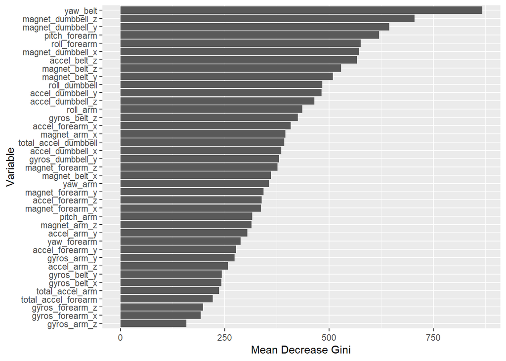

```r
#plot importance in variable
importance<-data.frame(fit_rf$finalModel$importance)
importance$variable<-row.names(importance)
ggplot(importance, aes(x = MeanDecreaseGini, y = reorder(variable,MeanDecreaseGini))) + geom_col() + ylab("Variable") + xlab("Mean Decrease Gini")
```

## Testing data

```r
##setting variables format and deleting unnecessary variables
subset_test<-as.data.frame(apply(testing[,8:dim(testing)[2]],2,as.numeric))

##Deleting variable with mostly NA values
noNATest<-subset_test[,which(apply(subset_test,2, function(x) sum(is.na(x)))<20)]

##correlated variables
test_new <- noNATest[,!apply(M,2,function(x) any(abs(x) > 0.8))]
test_new$problem_id<-as.factor(testing$problem_id)
dim(test_new)
```

```
## [1] 20 40
```

## Predictions

Finally I will predict the execution of the movement in the 20 cases included in the test data set, for this we will use the random forest model.

```r
##predicting testing data
pred_test_rf<-predict(fit_rf,test_new)
data.frame(prediction=pred_test_rf,problem_id=test_new$problem_id)
```

```
##    prediction problem_id
## 1           B          1
## 2           A          2
## 3           B          3
## 4           A          4
## 5           A          5
## 6           E          6
## 7           D          7
## 8           B          8
## 9           A          9
## 10          A         10
## 11          B         11
## 12          C         12
## 13          B         13
## 14          A         14
## 15          E         15
## 16          E         16
## 17          A         17
## 18          B         18
## 19          B         19
## 20          B         20
```